# Practical Machine Learning Course Project

Koid Liang Imm

December 22, 2015

# Background

Using devices such as Jawbone Up, Nike FuelBand, and Fitbit it is now possible to collect a large amount of data about personal activity relatively inexpensively. These type of devices are part of the quantified self movement  a group of enthusiasts who take measurements about themselves regularly to improve their health, to find patterns in their behavior, or because they are tech geeks. One thing that people regularly do is quantify how much of a particular activity they do, but they rarely quantify how well they do it. This project will use data from accelerometers on the belt, forearm, arm, and dumbell of 6 participants. They were asked to perform barbell lifts correctly and incorrectly in 5 different ways.

More information is available from the website here: http://groupware.les.inf.puc-rio.br/har (see the section on the Weight Lifting Exercise Dataset).

# Data Sources

The training data for this project are available here: https://d396qusza40orc.cloudfront.net/predmachlearn/pml-training.csv

The test data are available here: https://d396qusza40orc.cloudfront.net/predmachlearn/pml-testing.csv

The data for this project come from this source: http://groupware.les.inf.puc-rio.br/har. If you use the document you create for this class for any purpose please cite them as they have been very generous in allowing their data to be used for this kind of assignment.

# Loading Libraries

```r
rm(list=ls())
library(caret)
library(randomForest)
library(gbm)
library(plyr)
```

# Getting Data

```r
setwd("C://Imm Document//Coursea")
raw.data<-read.csv("pml-training.csv",na.strings = c("NA", ""))
submit.data<-read.csv("pml-testing.csv")
```

After loading the data we can do an initial overview for the data:

```r
nrow(raw.data)
```

```
## [1] 19622
```

```r
ncol(raw.data)
```

```
## [1] 160
```

```r
str(raw.data,list.len=15)
```

```
## 'data.frame':    19622 obs. of  160 variables:
##  $ X                       : int  1 2 3 4 5 6 7 8 9 10 ...
##  $ user_name               : Factor w/ 6 levels "adelmo","carlitos",..: 2 2 2 2 2 2 2 2 2 2 ...
##  $ raw_timestamp_part_1    : int  1323084231 1323084231 1323084231 1323084232 1323084232 1323084232 1323084232 1323084232 1323084232 1323084232 ...
##  $ raw_timestamp_part_2    : int  788290 808298 820366 120339 196328 304277 368296 440390 484323 484434 ...
##  $ cvtd_timestamp          : Factor w/ 20 levels "02/12/2011 13:32",..: 9 9 9 9 9 9 9 9 9 9 ...
##  $ new_window              : Factor w/ 2 levels "no","yes": 1 1 1 1 1 1 1 1 1 1 ...
##  $ num_window              : int  11 11 11 12 12 12 12 12 12 12 ...
##  $ roll_belt               : num  1.41 1.41 1.42 1.48 1.48 1.45 1.42 1.42 1.43 1.45 ...
##  $ pitch_belt              : num  8.07 8.07 8.07 8.05 8.07 8.06 8.09 8.13 8.16 8.17 ...
##  $ yaw_belt                : num  -94.4 -94.4 -94.4 -94.4 -94.4 -94.4 -94.4 -94.4 -94.4 -94.4 ...
##  $ total_accel_belt        : int  3 3 3 3 3 3 3 3 3 3 ...
##  $ kurtosis_roll_belt      : Factor w/ 396 levels "-0.016850","-0.021024",..: NA NA NA NA NA NA NA NA NA NA ...
##  $ kurtosis_picth_belt     : Factor w/ 316 levels "-0.021887","-0.060755",..: NA NA NA NA NA NA NA NA NA NA ...
##  $ kurtosis_yaw_belt       : Factor w/ 1 level "#DIV/0!": NA NA NA NA NA NA NA NA NA NA ...
##  $ skewness_roll_belt      : Factor w/ 394 levels "-0.003095","-0.010002",..: NA NA NA NA NA NA NA NA NA NA ...
##   [list output truncated]
```

So there are 19622 observations in the data set. Every observation contains 160 variables.

# Data clean and preprocessing

## Removing NA and “” columns

160 variables are too big for compter processing, and we need do the data clean and preprocesing firstly.

From simple observation, we can find the first seven columns of the raw data only contain the information of Removing first cols which only including log information like seq No, use_name, time_stamp etc. These log info are not related to the activity measurements. We also can see that there are many NAs and “” in some columns. So as the first step data cleaning, we can remove these columns

```r
## Removing first 7 cols which only including log info seq No, user_name,time_stamp etc info
clean.data<-raw.data[, -(1:7)]

## Removing cols only containing NA or ""
thres <- nrow(clean.data) * 0.95  ## Setting threshoold as more than95% of NAs or ""
nNaColumns <- !apply(clean.data, 2, function(x) sum(is.na(x)) > thres  || sum(x=="") > thres)
clean.data <- clean.data[, nNaColumns]

rm(raw.data)  # delete raw.data
```

# Removing near zero variance columns

As the next step of the data cleaning, we can further removing those columns which value nearly no changing. This is can be performed with nearZeroVar function in caret package.

```r
nzColumns <- nearZeroVar(clean.data, saveMetrics = TRUE)
clean.data <- clean.data[, nzColumns$nzv==FALSE]
clean.data$classe = factor(clean.data$classe)
```

Now, there are only 53 columns left.

# Removing non-important columns

With above data processing, we succeed reducing the data set variable number from 160 to 53. But for the computer memory limitions, some r classification methods such as Random Forest classification etc are still dificult to perform. So I have to further reduce the data variables number.

From some initial testing, we can find Random Forest method has the highest classification accuracy, so the further data processing is based on the RF classification.

Firstly, using RF method training a small section (20%) of the data set.

```r
## Vars importances analysis
set.seed(12345)
inAnalysis <- createDataPartition(clean.data$classe, p = 0.2, list = FALSE)
analysis.set <- clean.data[inAnalysis, ]  ##  20% data for importance analysis
modanalysis<-randomForest(classe ~.,data=analysis.set)
```

The next step is do the variable importance analysis for this model via varImp function:

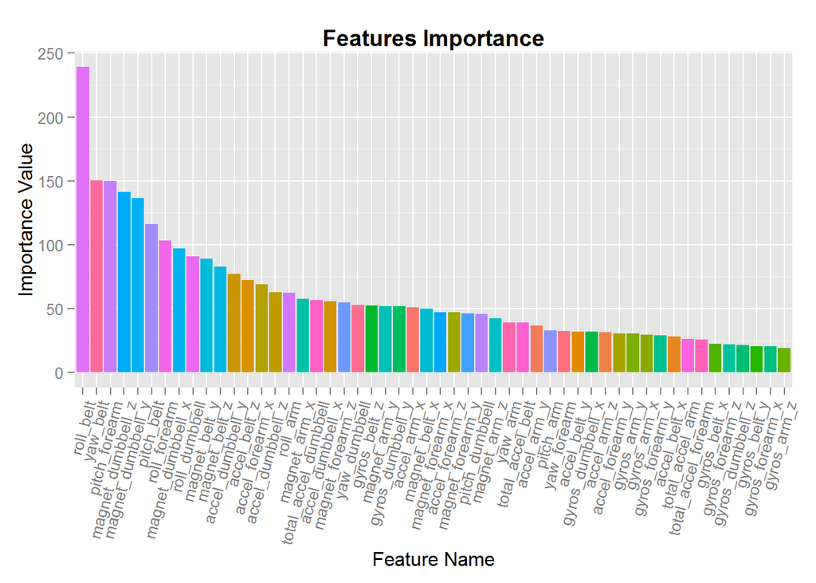

```r
impVars <- varImp(modanalysis)
varnames<-rownames(impVars)
varOrders<-data.frame(varnames=varnames,impVars)
varOrders<-arrange(varOrders,desc(Overall))
ggplot(varOrders, aes(x=reorder(varnames,desc(Overall)),y=Overall,fill=varnames)) +
  geom_bar(stat="identity") + theme(legend.position="none")+
  xlab("Feature Name")+guides(fill=FALSE)+
  ylab("Importance Value")+ggtitle("Features Importance")+
  theme(axis.text.x=element_text(angle=75,hjust=1)) +
  theme(plot.title = element_text(size=14, face="bold"))
```

```r
varOrders[1:40,]
```

```
##                varnames   Overall
## 1             roll_belt 239.10778
## 2              yaw_belt 150.07990
## 3         pitch_forearm 149.89685
## 4     magnet_dumbbell_z 141.34234
## 5     magnet_dumbbell_y 136.54083
## 6            pitch_belt 116.07684
## 7          roll_forearm 103.01858
## 8     magnet_dumbbell_x  97.15155
## 9         roll_dumbbell  90.98209
## 10        magnet_belt_y  89.21668
## 11        magnet_belt_z  82.72191
## 12     accel_dumbbell_y  76.94885
## 13         accel_belt_z  72.20202
## 14      accel_forearm_x  69.04534
```

[output cut: 26 more lines]

From above variables importance analysis, we can see that different variables’ importance values varies too much, so we further try to trim those unimportant variables form the data set.

In the implemenatation, I trimed out those variables whose importance value less than 30:

```r
impNames<-as.character(varOrders[varOrders$Overall>30,]$varnames)
impNames<-c("classe",impNames)
topImpCols<-unlist(lapply(names(clean.data), function(name){name %in% impNames}))

clean.data<-clean.data[,topImpCols]
ncol(clean.data)
```

```
## [1] 42
```

# Data partition

Now, we can do the data set partition

```r
inTrain <- createDataPartition(clean.data$classe, p = 0.75, list = FALSE)
train.set <- clean.data[inTrain, ]  ##  75% data as the train data
test.set <- clean.data[ -inTrain, ]
```

# Prediction models training

The selected prediction models are Random Forest and KNN methods.

```r
modRF<-randomForest(classe ~.,data=train.set)
ctrlKNN = trainControl(method = "adaptive_cv")
modKNN = train(classe ~ ., data=train.set, method = "knn", trControl = ctrlKNN)
```

# Cross-Validation and out of sample error estimating;

With the trained models, can do the cross-validation on the testing data set:

```r
predRF<-predict(modRF,test.set)
rfMatrix<-confusionMatrix(predRF, test.set$classe)
rfMatrix
```

```
## Confusion Matrix and Statistics
##
##           Reference
## Prediction    A    B    C    D    E
##          A 1393    3    0    0    0
##          B    0  943    8    0    0
##          C    2    3  846    6    0
##          D    0    0    1  798    6
##          E    0    0    0    0  895
##
## Overall Statistics
##
##                Accuracy : 0.9941
##                  95% CI : (0.9915, 0.996)
##     No Information Rate : 0.2845
##     P-Value [Acc > NIR] : < 2.2e-16
##
##                   Kappa : 0.9925
##  Mcnemar's Test P-Value : NA
##
## Statistics by Class:
##
##                      Class: A Class: B Class: C Class: D Class: E
## Sensitivity            0.9986   0.9937   0.9895   0.9925   0.9933
## Specificity            0.9991   0.9980   0.9973   0.9983   1.0000
## Pos Pred Value         0.9979   0.9916   0.9872   0.9913   1.0000
## Neg Pred Value         0.9994   0.9985   0.9978   0.9985   0.9985
## Prevalence             0.2845   0.1935   0.1743   0.1639   0.1837
## Detection Rate         0.2841   0.1923   0.1725   0.1627   0.1825
## Detection Prevalence   0.2847   0.1939   0.1748   0.1642   0.1825
## Balanced Accuracy      0.9989   0.9958   0.9934   0.9954   0.9967
```

```r
predKNN<-predict(modKNN,test.set)
knnMatrix<-confusionMatrix(predKNN, test.set$classe)
knnMatrix
```

```
## Confusion Matrix and Statistics
##
##           Reference
## Prediction    A    B    C    D    E
##          A 1336   47    8    9   14
##          B    9  836   34    4   41
##          C   14   31  780   53   18
##          D   30   21   22  731   30
##          E    6   14   11    7  798
##
## Overall Statistics
##
##                Accuracy : 0.9137
##                  95% CI : (0.9055, 0.9215)
##     No Information Rate : 0.2845
##     P-Value [Acc > NIR] : < 2.2e-16
##
##                   Kappa : 0.8909
##  Mcnemar's Test P-Value : 3.97e-16
##
## Statistics by Class:
##
##                      Class: A Class: B Class: C Class: D Class: E
## Sensitivity            0.9577   0.8809   0.9123   0.9092   0.8857
## Specificity            0.9778   0.9777   0.9714   0.9749   0.9905
## Pos Pred Value         0.9448   0.9048   0.8705   0.8765   0.9545
## Neg Pred Value         0.9831   0.9716   0.9813   0.9821   0.9747
## Prevalence             0.2845   0.1935   0.1743   0.1639   0.1837
## Detection Rate         0.2724   0.1705   0.1591   0.1491   0.1627
## Detection Prevalence   0.2883   0.1884   0.1827   0.1701   0.1705
## Balanced Accuracy      0.9677   0.9293   0.9418   0.9420   0.9381
```

For Random Forest method has the lower out of sample error rate, we select it as the final prediction model ad use it to predict needed 20 different test cases.

# Submitting cases

The predicting results as below:

```r
## Submission Predict
answer <- predict(modRF, submit.data)
answer
```

```
##  1  2  3  4  5  6  7  8  9 10 11 12 13 14 15 16 17 18 19 20
##  B  A  B  A  A  E  D  B  A  A  B  C  B  A  E  E  A  B  B  B
## Levels: A B C D E
```

Submitting above result to the grader, we can get the perfect 100% correctness.

# Conclusion

Implementing the model to 20 test cases, the predicting got the 100% correctness rate.